# Datasets Exploratory Analysis for Predictive Text Modelling

Karthik Kalimuthu

Sunday, August 28, 2016

# Introduction

This report consist of information related to text datasets exploratory analysis performed for the end purpose of building a Predictive Text Model Shinny application in near future.

# Procedure

This section consist of information related to getting and cleaning the datasets followed by procedures taken to represent the datasets as `Corpus` R Objects.

## Getting the Data

1. The datasets consist of 4 locales and for the purpose of this report, only the datasets under `en_US` were considered.
2. Below shows the individual file size under `en_US` folder.

```
##                name      size
## 1   en_US.blogs.txt 200.42 MB
## 2    en_US.news.txt 196.28 MB
## 3 en_US.twitter.txt 159.36 MB
```

## Sampling the Data

1. Based on information from Getting the Data Section. It was decided to sample 1% of the dataset.
2. Below shows the individual sampled file size.

```
##                name    size
## 1   en_US.blogs.txt 2.01 MB
## 2    en_US.news.txt 1.97 MB
## 3 en_US.twitter.txt  1.6 MB
```

## Construct Corpus

This section describes the creation of `Corpus` in R as a representation of multiple text documents and the procedures taken to preprocess it.

1. Built `Corpus` using R Package “tm” with text documents described in the Sample the Data section.

```
## <<VCorpus>>
## Metadata:  corpus specific: 0, document level (indexed): 0
## Content:  documents: 3
```

```
## <<TermDocumentMatrix (terms: 58645, documents: 3)>>
## Non-/sparse entries: 88455/87480
## Sparsity           : 50%
## Maximal term length: 123
## Weighting          : term frequency (tf)
```

```
## <<TermDocumentMatrix (terms: 9969, documents: 3)>>
## Non-/sparse entries: 29907/0
## Sparsity           : 0%
## Maximal term length: 16
## Weighting          : term frequency (tf)
```

# Data Exploratory Analysis

The section attempts to present the exploratory analysis based on the `Corpus` created from the Construct Corpus section.

## Word Cloud

A visual representation of 170 words that appears in the `Corpus` as brief linguistic context.

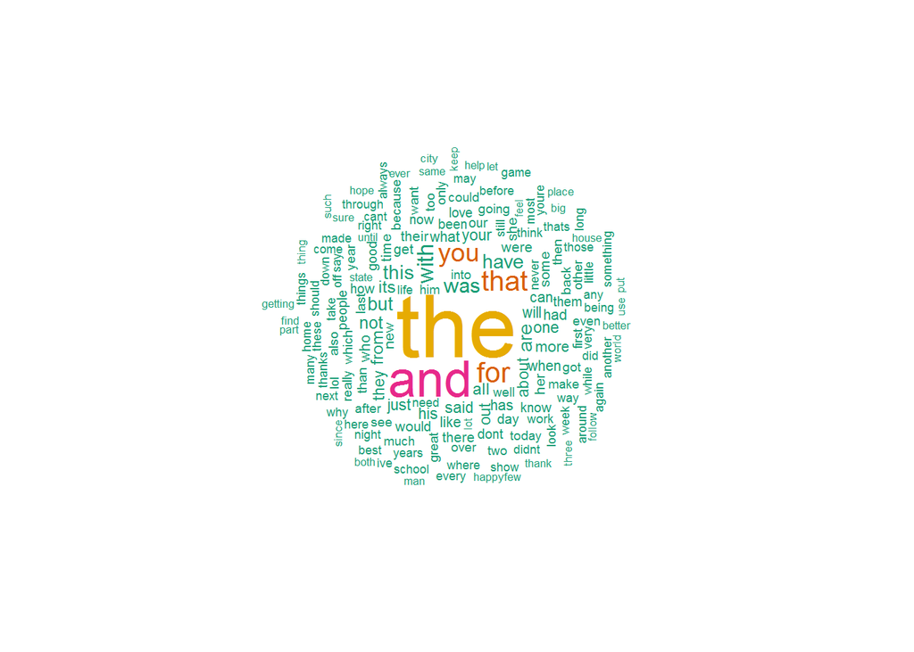